# 第7回 確率を出し、誤りの重さでしきい値を決める

ロジスティック回帰とパイプライン

# 導入

## 前回：線形回帰で判定した

① 場面●○○○○

- 心臓病（1）とそうでない（0）を線形回帰で当て、0.5で切って判定した
- 見逃しと誤検出を分けて数え、しきい値を動かすと入れ替わることを見た

## 前回、言えなかったこと

① 場面●●○○○

- 式の値は0〜1をはみ出し、確率とは呼べなかった
- しきい値をどこに決めるかも、まだ決めていない

## 場面：同じ循環器外来

① 場面●●●○○

- あなたは、前回と同じ循環器外来の医師
- 胸の痛みなどで受診した患者に、冠動脈造影を受けてもらうかを決める

## 確率で伝えたい

① 場面●●●●○

- 患者には「心臓病である確率は、およそ3割です」と伝えたい
- どの確率から造影を勧めるかを、理由を付けて決めたい

## 決めたいこと

① 場面●●●●●

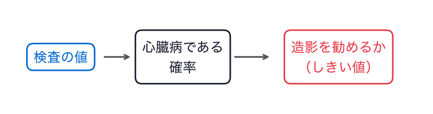

- 検査の値から確率を出し、しきい値で造影を勧めるかを決める

## 手元のデータ

② 手元のデータ●

- 前回と同じ、クリーブランド・クリニックで造影を受けた患者303人（Detranoほか, 1989）
- 1行が1人。13本の検査値と、造影で心臓病と分かったか（1/0）
- 前処理も前回と同じ。297人・18本の手がかり

## 最後に出す答え

③ 今日の問い●○

- 新しく来た患者の、心臓病である確率
- その確率から、造影を勧めるかどうかの判定
- そのしきい値を選んだ理由

## 今日の問い

③ 今日の問い●●

検査の値から心臓病である確率を出し、どの確率から造影を勧めるかを、どう決めるか？

## もう1つのねらい：fitの正体

④ もう1つのねらい●○

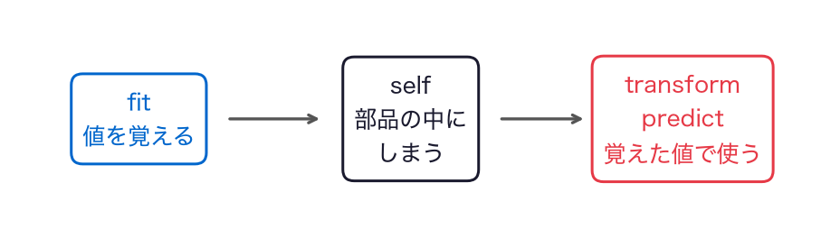

- `fit`や`predict`の正体（クラスとメソッド）を、読めるようになる

## 小さな部品を自分で書く

④ もう1つのねらい●●

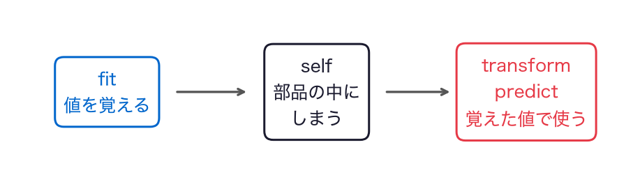

- 標準化の部品を、`fit`と`transform`を持つクラスで書く
- scikit-learnの部品と同じ形だと確かめ、パイプラインでつなぐ

## この問いにどう近づくか

⑤ 今日の問い●○

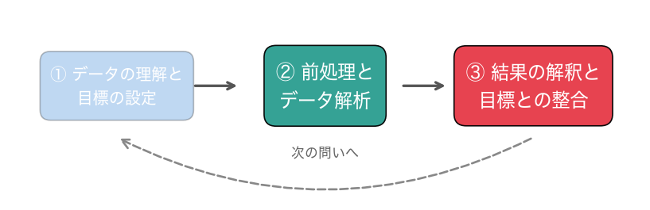

②の前処理と解析を1本にまとめ、③で確率を読み、しきい値を決めます。

## 今日の道筋

⑤ 今日の問い●●

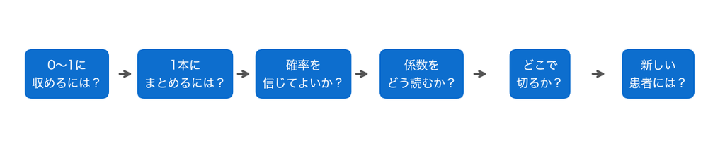

- 6つの小さな問いに答えていく

# 0. 準備

## まずは道具とデータ

- 第7回のノートを開き、上から順にセルを実行する
- 前回と同じ手順で、手がかりの表を作る

## お手本：道具を呼び出す

0節 ① 道具とデータ●○○○

```python
import numpy as np
import pandas as pd
import matplotlib.pyplot as plt
from sklearn.linear_model import LinearRegression, LogisticRegression
from sklearn.preprocessing import StandardScaler
from sklearn.pipeline import make_pipeline
from sklearn.model_selection import train_test_split, StratifiedKFold
from sklearn.model_selection import cross_val_score, cross_val_predict
from sklearn.metrics import confusion_matrix, roc_auc_score
```

- 確率を出す道具、標準化の部品、部品をつなぐ道具が加わる

## お手本：前回と同じ手順

0節 ① 道具とデータ●●○○

```python
# データはこのリポジトリから読み込む
DATA_DIR = ('https://raw.githubusercontent.com/k0heiun0/'
            'applied_exercise_preview/main/shared/data')
raw = pd.read_csv(f'{DATA_DIR}/heart.csv')
ja_names = {'age': '年齢', 'sex': '性別', 'cp': '胸痛の種類',
            'trestbps': '安静時血圧', 'chol': 'コレステロール',
            'fbs': '空腹時血糖', 'restecg': '安静時心電図',
            'thalach': '最大心拍数', 'exang': '運動時の胸痛',
            'oldpeak': 'ST低下', 'slope': 'STの傾き',
            'ca': '血管の数', 'thal': 'タリウム検査',
            'target': '心臓病'}
df = raw.rename(columns=ja_names).dropna().reset_index(drop=True)
kinds = ['胸痛の種類', '安静時心電図', 'STの傾き', 'タリウム検査']
X = pd.get_dummies(df.drop(columns='心臓病'), columns=kinds,
                   drop_first=True, dtype=int)
y = df['心臓病']
X_tr, X_te, y_tr, y_te = train_test_split(
    X, y, test_size=0.2, random_state=0, stratify=y)
y_true = y_te.values                 # 答えを、ただの並びにする
print(len(df), '人', X.shape)
print(len(X_tr), len(X_te), y_te.sum(), '人がテストの心臓病')
```

## 前回の0節と1節を1つに

0節 ① 道具とデータ●●●○

- 列名を日本語に → 欠測の6人を外す → 区分の4本をダミー変数に
- `stratify=y`で、割合をそろえて訓練とテストに分ける
- 各列の中身は、前回のノートの表で確かめる

## 297人、18本

0節 ① 道具とデータ●●●●

```
297 人 (297, 18)
237 60 28 人がテストの心臓病
```

- 訓練237人、テスト60人。テストの心臓病は28人
- 前回と同じ分け方なので、テストの60人も同じ人たち

## やってみよう：0節

0節 ② 確かめる●

- 0節のセルを上から実行し、297人と18本を確かめる

動画の人は、ここで一時停止。

# 1. 0〜1に収めるには？

## はみ出しを思い出す

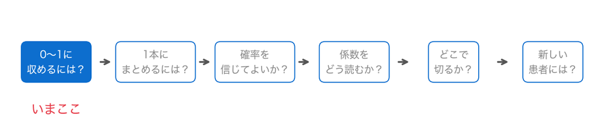

- 前回の線形回帰の式の値が、どれだけ0〜1をはみ出していたか

## おさらい：線形回帰の式の値

1節 ① はみ出し●○○

```python
m = LinearRegression().fit(X_tr, y_tr)
s = m.predict(X_te)                 # テストの人の、式の値
print(round(s.min(), 2), round(s.max(), 2))
print(round(roc_auc_score(y_true, s), 3))
print(round(s[0], 2))               # テストの1人目
```

```
-0.21 1.17
0.929
0.33
```

## −0.21から1.17

1節 ① はみ出し●●○

[figure not shown]

- 灰色の帯は0〜1の外。直線の式は、0を下回り1を超える
- AUCは0.929。テストの1人目は0.33で「でない」と判定

## 0〜1に押し込むには？

1節 ① はみ出し●●●

- 式の値を、0〜1の範囲に押し込む関数に通せばよさそう

## シグモイド関数

1節 ② シグモイド●○○○

$$\sigma(z) = \frac{1}{1 + e^{-z}}$$

- どんな数$z$も、0から1の間の数に変える
- $e$は自然対数の底（約2.718）

## 端では0と1に近づく

1節 ② シグモイド●●○○

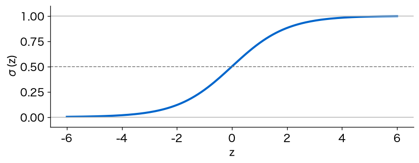

- $z$が大きいと$e^{-z}$は0に近づき、$\sigma(z)$は1へ
- マイナスに大きいと0へ。$z = 0$でちょうど0.5

## お手本：5つの数を通す

1節 ② シグモイド●●●○

```python
z = np.array([-4, -2, 0, 2, 4])
print((1 / (1 + np.exp(-z))).round(3))
```

```
[0.018 0.119 0.5   0.881 0.982]
```

- `np.exp(-z)`は、$e^{-z}$を並びの1つずつに計算する

## どれも0と1の間

1節 ② シグモイド●●●●

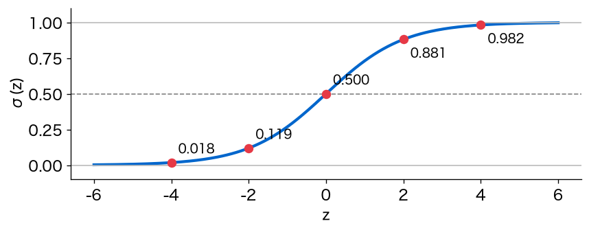

- −4は0.018、0は0.5、4は0.982。形はS字

## ロジスティック回帰

1節 ③ ロジスティック回帰●○○○

$$z_i = b_0 + b_1 x_{i1} + \cdots + b_{18} x_{i,18}, \qquad p_i = \sigma(z_i)$$

- 線形の式の値$z_i$を、シグモイド関数に通して確率$p_i$にする
- ロジスティック回帰（logistic regression）と呼ぶ。分類に使う

## 線形の式を、S字に通す

1節 ③ ロジスティック回帰●●○○

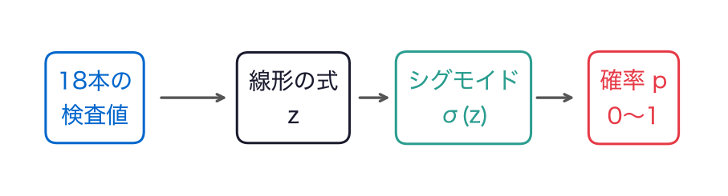

- 線形の式の部分は、これまでの線形回帰と同じ形

## 係数の決め方：尤度

1節 ③ ロジスティック回帰●●●○

$$L = \prod_{i=1}^{n} p_i^{\,y_i} (1 - p_i)^{1 - y_i}$$

- 心臓病の人には$p_i$を、でない人には$1 - p_i$をかけあわせる
- 尤度（likelihood）：その係数のもとで、実際の答えの並びが出る確率

## 当たるほど大きい

1節 ③ ロジスティック回帰●●●●

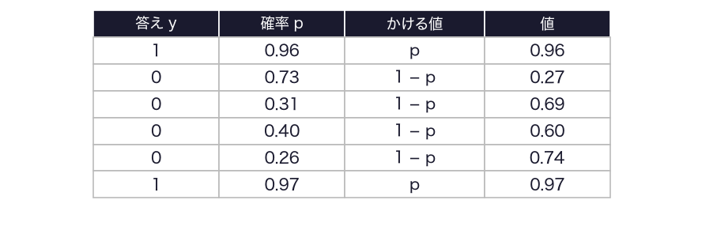

- 答えに合った確率を出すほど、かける値は1に近づく
- 尤度が最大になる係数を選ぶ。最尤法（maximum likelihood method）

## お手本：ロジスティック回帰

1節 ④ 警告を読む●○○○○○

```python
lr = LogisticRegression().fit(X_tr, y_tr)
```

- 使い方は`LinearRegression`と同じ。`fit(手がかり, 答え)`

## 赤い警告が出た

1節 ④ 警告を読む●●○○○○

```
ConvergenceWarning: lbfgs failed to converge after 100 iteration(s)
...
Increase the number of iterations to improve the convergence
(max_iter=100).
You might also want to scale the data as shown in: ...
```

- 第5回のラッソでも見た`ConvergenceWarning`

## 警告を読む

1節 ④ 警告を読む●●●○○○

- lbfgs（係数を探す計算の方法）が、100回くり返しても収束しなかった
- くり返しの回数を増やすとよい
- データの尺度をそろえる（scale）ことも考えるとよい

## なぜ収束しないか

1節 ④ 警告を読む●●●●○○

- 尤度を最大にする係数は、1回の計算では求まらない
- 係数を少しずつ動かす計算をくり返して探す
- 列ごとに値の大きさが大きく違うと、探し方が遠回りになる

## 変えてみる：列の大きさ

1節 ④ 警告を読む●●●●●○

```python
print(X_tr[['コレステロール', '最大心拍数', '性別']].std().round(2))
```

```
コレステロール    52.47
最大心拍数      23.03
性別          0.47
```

## 100倍ほど違う

1節 ④ 警告を読む●●●●●●

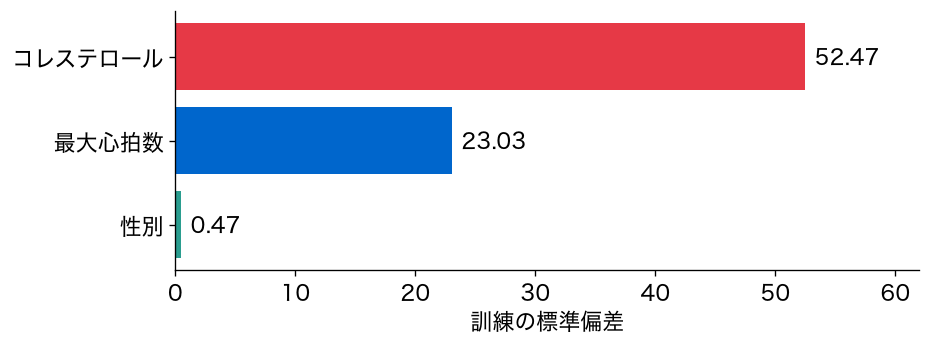

- コレステロール52.47、最大心拍数23.03、性別0.47
- 警告の言うとおり、尺度をそろえる。第3回と第5回の標準化

## お手本：標準化してから当てる

1節 ⑤ 標準化して当てる●○○○○

```python
def standardize(X, mean, std):
    return (X - mean) / std

mean_tr, std_tr = X_tr.mean(), X_tr.std()   # 訓練だけで決める
Z_tr = standardize(X_tr, mean_tr, std_tr)
Z_te = standardize(X_te, mean_tr, std_tr)
lr = LogisticRegression().fit(Z_tr, y_tr)
print(lr.predict_proba(Z_te)[:3].round(3))
```

- `standardize`は第5回と同じ。平均と標準偏差は訓練だけで決める（第3回）

## 警告は出ない

1節 ⑤ 標準化して当てる●●○○○

```
[[0.693 0.307]
 [0.006 0.994]
 [0.235 0.765]]
```

- `predict_proba`は、区分ごとの確率を返すメソッド
- probaは確率（probability）の略

## predict_probaの2つの列

1節 ⑤ 標準化して当てる●●●○○

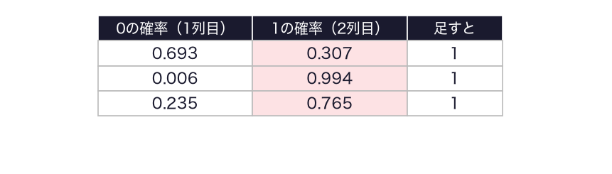

- 1列目は「心臓病でない」、2列目は「心臓病」の確率。足すと1
- 心臓病の確率は、2列目を`[:, 1]`で取り出す

## 変えてみる：2列目だけ

1節 ⑤ 標準化して当てる●●●●○

```python
prob = lr.predict_proba(Z_te)[:, 1]     # 2列目＝心臓病の確率
print(round(prob.min(), 3), round(prob.max(), 3))
print(prob[:5].round(2))
```

```
0.005 0.994
[0.31 0.99 0.77 0.92 0.94]
```

## 0.005から0.994

1節 ⑤ 標準化して当てる●●●●●

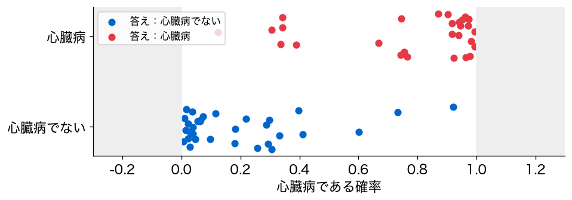

- すべて0〜1に収まった
- 1人目は0.31。前回の線形回帰では0.33だった

## ロジスティック回帰にも罰

1節 ⑥ 罰の強さC●○

- `LogisticRegression`には、初めから係数への罰（正則化）が付いている
- 第5回のリッジと同じ、係数の二乗の罰
- 罰の強さは引数`C`で決まる

## お手本：Cを確かめる

1節 ⑥ 罰の強さC●●

```python
print(lr.C)
```

```
1.0
```

- 既定値は1.0。`alpha`と向きが逆で、小さいほど罰が強い
- 罰をかけるなら、第5回と同じく、先に標準化しておく

## TODO①：0.5で切って評価

1節 ⑦ 0.5で評価●○○○○

```python
# TODO: prob を 0.5 で切って判定し、混同行列と AUC を表示する
# ヒント: pred = (prob >= 0.5).astype(int)（前回と同じ）
#         AUC は roc_auc_score(y_true, prob)
...
```

- 判定`pred`を作り、`confusion_matrix(y_true, pred)`とAUCを出す

## やってみよう：1節とTODO①

1節 ⑦ 0.5で評価●●○○○

- 1節のお手本と「変えてみる」のセルを実行する
- TODO①で、0.5で切った混同行列とAUCを出す

動画の人は、ここで一時停止。

## 答え合わせ：TODO①

1節 ⑦ 0.5で評価●●●○○

```python
pred = (prob >= 0.5).astype(int)
print(confusion_matrix(y_true, pred))
print(round(roc_auc_score(y_true, prob), 3))
```

```
[[29  3]
 [ 6 22]]
0.944
```

## 判定は前回と同じ

1節 ⑦ 0.5で評価●●●●○

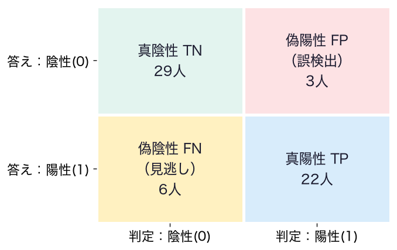

- 見逃し6人、誤検出3人。前回の線形回帰と同じ混同行列

## 変わったのは値の意味

1節 ⑦ 0.5で評価●●●●●

- AUCは0.944で、線形回帰の0.929より少し高い
- 0.5で切った判定は、変わらなかった
- 変わったのは、出てくる値が0〜1の確率になったこと

# 2. 1本にまとめるには？

## 手順は2段

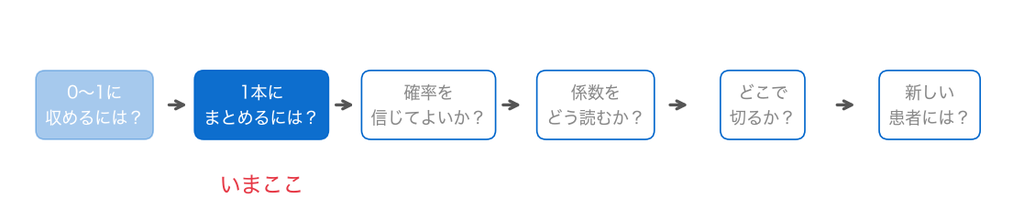

- 確率が出せた。ただし、標準化してから式に入れる、の2段
- 新しい患者のたびに、この2段を正しい順で書く

## 変えてみる：標準化を忘れると

2節 ① 忘れると●○○○

```python
p_forgot = lr.predict_proba(X_te)[:, 1]   # 標準化を忘れた
print((p_forgot >= 0.5).sum(), '人が「心臓病」')
```

```
54 人が「心臓病」
```

- わざと、1段目を飛ばしてみる

## 60人のうち54人

2節 ① 忘れると●●○○

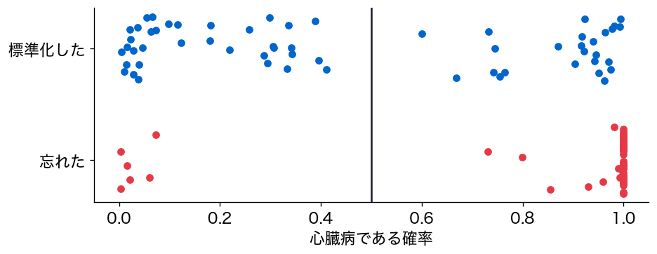

- 標準化を忘れると、ほとんどの人の確率が1に張り付く

## エラーは出ない

2節 ① 忘れると●●●○

- 式は、0のまわりにある（標準化した）値を待っている
- そこに、コレステロールなら200を超えるような元の値が入った
- エラーは出ないので、気づかないまま、おかしな確率を出す

## 覚えておく部品がほしい

2節 ① 忘れると●●●●

- 訓練の平均と標準偏差を覚えておく
- いつも同じ手順で使う
- そんな部品があれば、この誤りを防げる

## おさらい：def

2節 ② クラス●○○○○○○

```python
def standardize(X, mean, std):
    return (X - mean) / std
```

- `def`は、手順に名前を付けてまとめる書き方（第4回）
- ただ、平均と標準偏差を毎回渡す必要がある。覚えておく場所がない

## 名前：クラスとメソッド

2節 ② クラス●●○○○○○

- 値と手順をひとまとめにする書き方を、クラス（class）と呼ぶ
- クラスの中に書いた`def`を、メソッド（method）と呼ぶ

## お手本：標準化の部品

2節 ② クラス●●●○○○○

```python
class Standardizer:
    def fit(self, X):
        self.mean = X.mean()     # 訓練の平均を覚える
        self.std = X.std()       # 訓練の標準偏差を覚える
        return self

    def transform(self, X):
        return (X - self.mean) / self.std
```

## ブロックで読む

2節 ② クラス●●●●○○○

- `class Standardizer:`：部品の設計図を書く
- `def fit(self, X):`：覚えるメソッド。平均と標準偏差をしまう
- `def transform(self, X):`：使うメソッド。しまった値で標準化する

## selfは、この部品自身

2節 ② クラス●●●●●○○

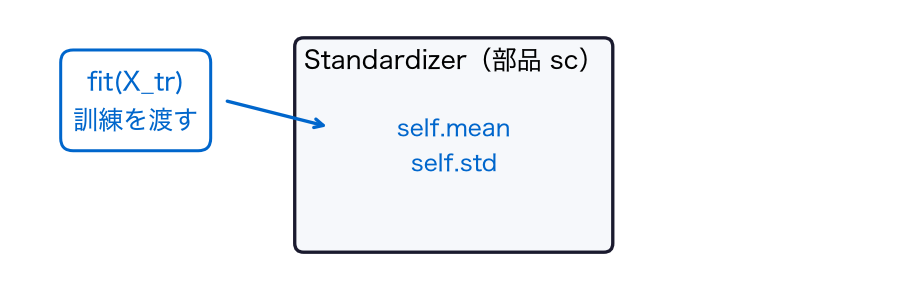

- `self.mean = ...`で、部品の中に`mean`という値がしまわれる
- あとで別のメソッドから`self.mean`で取り出せる

## fitでしまい、transformで使う

2節 ② クラス●●●●●●○

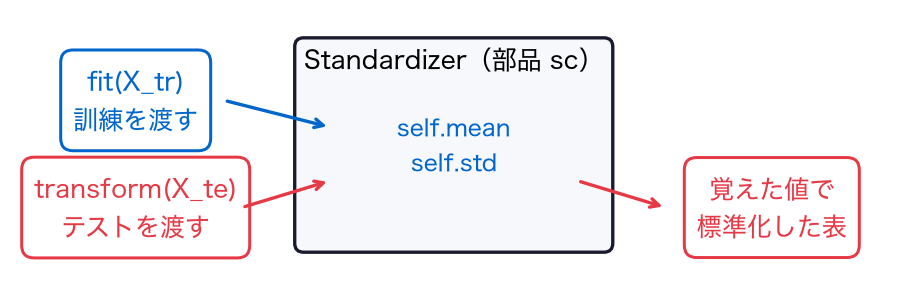

- `transform`は、`fit`でしまった訓練の値を使う

## return selfで、続けて書ける

2節 ② クラス●●●●●●●

- `fit`の最後の`return self`は、部品自身を返す
- だから`Standardizer().fit(X_tr)`のように、作ってすぐ`fit`した部品を受け取れる

## お手本：部品を使う

2節 ③ 部品を使う●○

```python
sc = Standardizer().fit(X_tr)          # 訓練で覚える
print(sc.mean[['年齢', 'コレステロール']].round(2))
print(sc.transform(X_te).iloc[:3, :3].round(3))
```

- `Standardizer()`で、設計図から部品を1つ作る

## 訓練の平均を覚えている

2節 ③ 部品を使う●●

```
年齢          54.32
コレステロール    248.62
       年齢     性別  安静時血圧
69 -0.921  0.692  1.112
2   1.403  0.692 -0.656
94 -0.257  0.692 -0.185
```

- 年齢54.32歳、コレステロール248.62
- 新しい患者が来ても、`sc.transform`に渡すだけ

## 変えてみる：本物と比べる

2節 ④ 本物と比べる●○○○○○○○○

```python
ss = StandardScaler().fit(X_tr)
print(ss.transform(X_te)[:3, :3].round(3))
```

```
[[-0.923  0.694  1.114]
 [ 1.406  0.694 -0.658]
 [-0.257  0.694 -0.185]]
```

- scikit-learnの標準化の部品。同じ`fit`と`transform`を持つ

## 小数第3位でずれる

2節 ④ 本物と比べる●●○○○○○○○

```
       年齢     性別  安静時血圧
69 -0.921  0.692  1.112
2   1.403  0.692 -0.656
94 -0.257  0.692 -0.185
[[-0.923  0.694  1.114]
 [ 1.406  0.694 -0.658]
 [-0.257  0.694 -0.185]]
```

- 1人目の年齢は、自分の部品で−0.921、`StandardScaler`で−0.923

## ドキュメントを読む

2節 ④ 本物と比べる●●●○○○○○○

```
We use a biased estimator for the standard deviation, equivalent to
`numpy.std(x, ddof=0)`.
```

- `help(StandardScaler)`のNotesの節
- 「標準偏差には、偏りのある推定量を使う。`numpy.std(x, ddof=0)`と同じ」

## 標準偏差の割り方は2通り

2節 ④ 本物と比べる●●●●○○○○○

$$\sqrt{\frac{1}{n}\sum_{i=1}^{n}(x_i - \bar{x})^2}
\quad \text{と} \quad
\sqrt{\frac{1}{n-1}\sum_{i=1}^{n}(x_i - \bar{x})^2}$$

- `ddof=0`は$n$で割る（左）、`ddof=1`は$n - 1$で割る（右）

## ずれた理由

2節 ④ 本物と比べる●●●●●○○○○

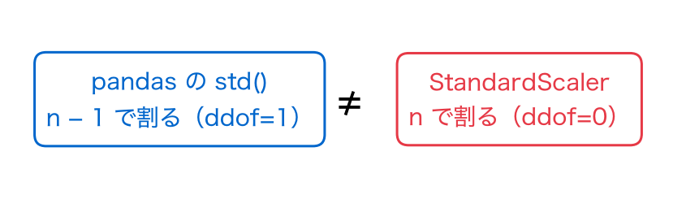

- pandasの`std()`は、何も書かないと`ddof=1`
- `StandardScaler`は`ddof=0`なので、ずれた

## TODO②：本物にそろえる

2節 ④ 本物と比べる●●●●●●○○○

```python
# TODO: ddof=0 にした Standardizer0 を書き、StandardScaler と比べる
# ヒント: class Standardizer0: の中身はお手本と同じで、
#         self.std = X.std(ddof=0) にする
...
```

- 訓練で`fit`し、テストの先頭3人・3列を`transform`して比べる

## やってみよう：TODO②

2節 ④ 本物と比べる●●●●●●●○○

- 2節のお手本と「変えてみる」のセルを実行する
- TODO②で、自分の部品を`StandardScaler`にそろえる

動画の人は、ここで一時停止。

## 答え合わせ：TODO②

2節 ④ 本物と比べる●●●●●●●●○

```python
class Standardizer0:
    def fit(self, X):
        self.mean = X.mean()
        self.std = X.std(ddof=0)   # n で割る
        return self

    def transform(self, X):
        return (X - self.mean) / self.std

sc0 = Standardizer0().fit(X_tr)
print(sc0.transform(X_te).iloc[:3, :3].round(3))
print(ss.transform(X_te)[:3, :3].round(3))
```

## 同じ数になった

2節 ④ 本物と比べる●●●●●●●●●

```
       年齢     性別  安静時血圧
69 -0.923  0.694  1.114
2   1.406  0.694 -0.658
94 -0.257  0.694 -0.185
[[-0.923  0.694  1.114]
 [ 1.406  0.694 -0.658]
 [-0.257  0.694 -0.185]]
```

- 1人目の年齢は−0.923。自分の部品と本物は、同じ形で同じ計算
- `ddof`の違いが当たりに効くことは、ふつうはない（ドキュメントの注）

## お手本：覚えた値を見る

2節 ⑤ 同じ形の部品●○○

```python
print(ss.mean_[:2].round(2))     # 年齢、性別の平均
print(ss.scale_[:2].round(2))    # 年齢、性別の標準偏差
```

```
[54.32  0.68]
[9.02 0.47]
```

- 自分の部品の`self.mean`・`self.std`にあたるのが`mean_`と`scale_`

## 最後の_は「fitで覚えた」

2節 ⑤ 同じ形の部品●●○

- 名前の最後の`_`は、「`fit`で覚えた値」の印
- これまで使ってきた`coef_`（係数）も同じ
- 年齢の平均54.32は、自分の部品が覚えた値と同じ

## モデルも同じ形

2節 ⑤ 同じ形の部品●●●

- `LogisticRegression`は、`fit`で係数を`coef_`に覚える
- `predict_proba`で、覚えた係数を使って確率を出す
- scikit-learnの部品はどれも、`fit`で覚え、`transform`や`predict`で使う

## 名前：パイプライン

2節 ⑥ パイプライン●○○○○

- 同じ形の部品は、順につなげられる
- 部品を順に並べたものを、パイプライン（pipeline）と呼ぶ
- `make_pipeline(部品1, 部品2)`で、部品を順につなぐ

## お手本：1本のパイプラインに

2節 ⑥ パイプライン●●○○○

```python
pipe = make_pipeline(StandardScaler(), LogisticRegression())
pipe.fit(X_tr, y_tr)
p_te = pipe.predict_proba(X_te)[:, 1]   # 元の値を渡すだけ
print(p_te[:5].round(2))
```

- 訓練もテストも、標準化していない元の値を渡す

## 1節と同じ確率

2節 ⑥ パイプライン●●●○○

```
[0.31 0.99 0.77 0.92 0.94]
[0.31 0.99 0.77 0.92 0.94]
```

- 上がパイプライン、下が1節で手で標準化したとき。小数第2位まで同じ
- 違うのは、標準偏差の`ddof`だけ

## fitのとき

2節 ⑥ パイプライン●●●●○

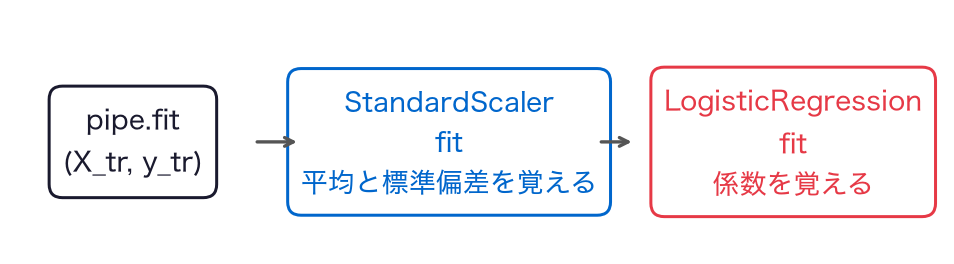

- 訓練の平均と標準偏差を覚えて訓練を標準化し、その表でモデルを`fit`する

## predict_probaのとき

2節 ⑥ パイプライン●●●●●

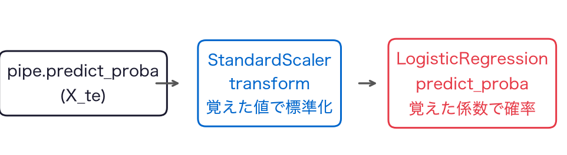

- 訓練で覚えた値で標準化してから、確率を出す
- 標準化を忘れることは、もうない

## お手本：パイプラインごと交差検証

2節 ⑦ 交差検証●○○○

```python
skf = StratifiedKFold(n_splits=5, shuffle=True, random_state=0)
auc_cv = cross_val_score(pipe, X, y, cv=skf, scoring='roc_auc')
print(auc_cv.round(3))
print(round(auc_cv.mean(), 3))
```

- パイプラインは、1つのモデルのように第5回の`cross_val_score`に渡せる
- `scoring='roc_auc'`でAUCを、`cv=skf`で前回の分け方を指定する

## AUCの平均は0.902

2節 ⑦ 交差検証●●○○

```
[0.945 0.93  0.9   0.824 0.912]
0.902
```

- 5回のAUCは0.824から0.945まで揺れる

## テストの1回は高いほう

2節 ⑦ 交差検証●●●○

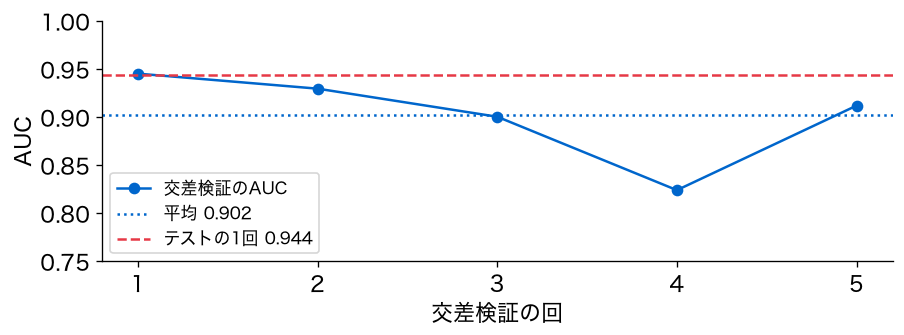

- テストの0.944は、5回の範囲の高いほうにあたる
- 前回の線形回帰の交差検証と、ほぼ同じ高さ。並べる力はほとんど変わらない

## 各回の中で標準化される

2節 ⑦ 交差検証●●●●

- `cross_val_score`は、各回の訓練でパイプラインを`fit`する
- 標準化の平均と標準偏差も、その回の訓練だけで決まる
- 第5回の`cv_model`で手で書いた標準化が、1行で済む

## やってみよう：2節

2節 ⑧ 確かめる●

- パイプラインのお手本と、交差検証のお手本を実行する
- 確率が1節と同じになることと、5回のAUCを確かめる

動画の人は、ここで一時停止。

# 3. その確率は信じてよいか？

## 確率0.3の人は3割か？

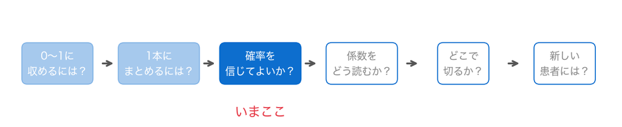

- 確率は0〜1に収まり、手順も1本になった
- 「確率0.3」と出た人たちは、本当に3割ほどが心臓病か

## 確かめ方：幅ごとに数える

3節 ① 確かめ方●○○

- 確率がおよそ0.3と出た人を集める
- その中で、実際に心臓病だった人の割合を数える
- それが0.3に近ければ、確率を信じてよさそう

## テストは60人と少ない

3節 ① 確かめ方●●○

- 幅ごとに分けると、テストでは数人ずつになってしまう
- そこで、訓練の237人で確かめる
- ただし、式を作るのに使った人の確率は、当たりやすい

## 式が見ていない確率を付ける

3節 ① 確かめ方●●●

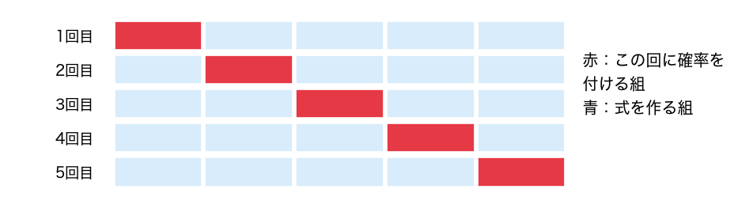

- 交差検証で、1人1人に、その人を使わずに作った式の確率を付ける

## お手本：cross_val_predict

3節 ② 式が見ていない確率●○

```python
p_cv = cross_val_predict(pipe, X_tr, y_tr, cv=skf,
                         method='predict_proba')[:, 1]
print(len(p_cv))
print(p_cv[:5].round(2))
```

- `cross_val_score`と同じ分け方で、評価の数ではなく1人1人の予測を返す
- `method='predict_proba'`で、確率を返すように指定する

## 237人に確率が付いた

3節 ② 式が見ていない確率●●

```
237
[0.01 0.09 0.58 0.09 0.82]
```

- 全員に、その人を使わずに作った式での確率が付いた

## 確率を5つの幅に分ける

3節 ③ 幅ごとの割合●○○○○

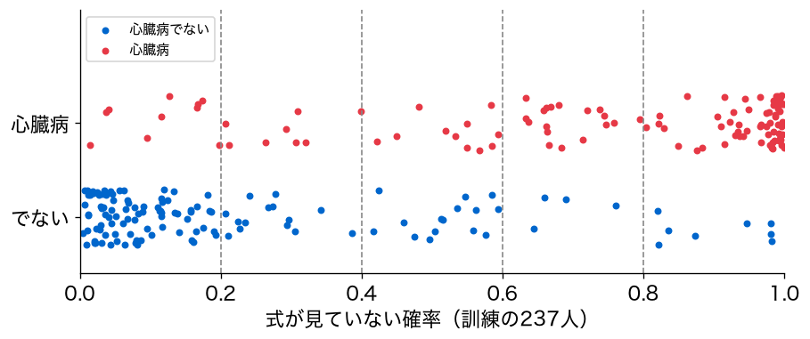

- 0.2刻みの5つの幅に分け、幅ごとに数える

## お手本：幅ごとの割合

3節 ③ 幅ごとの割合●●○○○

```python
check = pd.DataFrame({'確率': p_cv, '心臓病': y_tr.values})
check['幅'] = pd.cut(p_cv, [0, 0.2, 0.4, 0.6, 0.8, 1.0])
print(check['幅'].value_counts(sort=False))
print(check.groupby('幅', observed=True).mean().round(3))
```

- `pd.cut(値, 区切り)`は、値がどの幅に入るかを返す
- 分けたあとは、第3回からの`groupby`で幅ごとに平均する

## 1行ずつ読む

3節 ③ 幅ごとの割合●●●○○

- `(0.2, 0.4]`は、「0.2より大きく、0.4以下」
- 心臓病の列（1と0）の平均は、心臓病の人の割合
- `observed=True`は、人のいる幅だけを出す指定

## 幅ごとの人数

3節 ③ 幅ごとの割合●●●●○

```
幅
(0.0, 0.2]    97
(0.2, 0.4]    22
(0.4, 0.6]    26
(0.6, 0.8]    22
(0.8, 1.0]    70
```

- 0.2以下が97人、0.8より大きいが70人。まん中の幅は22〜26人

## 確率の平均と実際の割合

3節 ③ 幅ごとの割合●●●●●

```
               確率    心臓病
幅
(0.0, 0.2]  0.079  0.103
(0.2, 0.4]  0.277  0.364
(0.4, 0.6]  0.523  0.423
(0.6, 0.8]  0.692  0.818
(0.8, 1.0]  0.950  0.886
```

- 0.8より大きい70人：確率の平均0.95、実際0.886
- 0.2以下の97人：確率の平均0.079、実際0.103

## 対角線に沿っている

3節 ④ 較正●○○

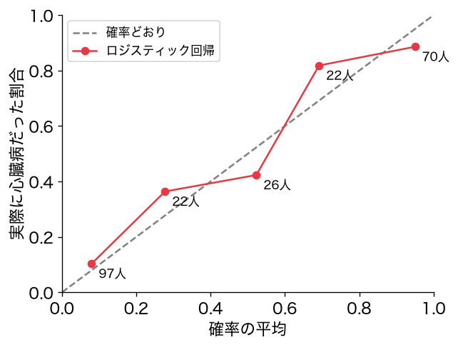

- 点は、おおむね対角線（確率どおり）に沿っている
- まん中の幅は人数が少なく、差が大きめに出る

## 名前：較正

3節 ④ 較正●●○

- 確率の値と、実際の割合が合っていること
- 確率の較正（calibration）がとれている、と言う

## 確率で伝える根拠

3節 ④ 較正●●●

- この確率なら、「確率はおよそ3割です」と伝えることに根拠がある
- 前回の線形回帰の値は1を超えることがあり、こう読めなかった

## やってみよう：3節

3節 ⑤ 確かめる●

- 3節のセルを実行し、幅ごとの確率の平均と実際の割合を確かめる

動画の人は、ここで一時停止。

# 4. 係数をどう読むか？

## どの検査値が効くか

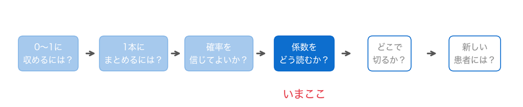

- 第4回は、線形回帰の係数を「1増えると何ドル」と読んだ
- ロジスティック回帰の係数は、どう読むか

## 確率は一定には増えない

4節 ① オッズ●○○

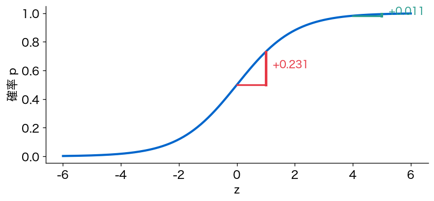

- $z$が1増えたときの確率の増え方は、$z$が0の近くか端かで違う

## 名前：オッズ

4節 ① オッズ●●○

$$\text{オッズ} = \frac{p}{1 - p}$$

- 「なる確率」が「ならない確率」の何倍か。オッズ（odds）と呼ぶ

## 確率とオッズ

4節 ① オッズ●●●

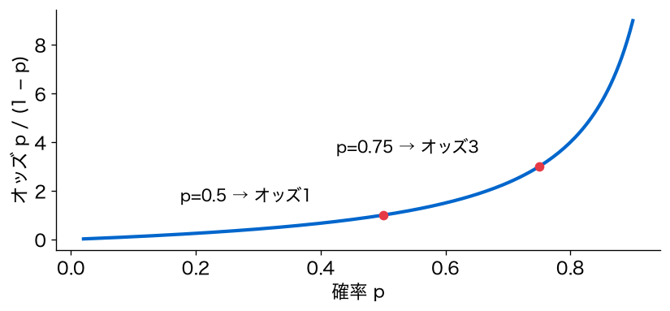

- 確率0.5ならオッズは1、確率0.75ならオッズは3（3対1）

## オッズの対数が線形の式

4節 ② オッズ比●○○○○○○

$$\log \frac{p}{1 - p} = z = b_0 + b_1 x_1 + \cdots + b_{18} x_{18}$$

- シグモイド関数の式を変形すると、こうなる
- $x_j$が1増えると、オッズの対数が$b_j$増える

## 名前：オッズ比

4節 ② オッズ比●●○○○○○

- オッズの対数が$b_j$増えると、オッズは$e^{b_j}$倍になる
- この$e^{b_j}$を、オッズ比（odds ratio）と呼ぶ
- 「何倍なりやすいか」をオッズで表す

## お手本：オッズ比を並べる

4節 ② オッズ比●●●○○○○

```python
coef = pd.Series(pipe[-1].coef_[0], index=X.columns)
print(np.exp(coef).round(2).sort_values())
```

- `pipe[-1]`で、パイプラインの最後の部品（ロジスティック回帰）
- `pipe[0]`なら、最初の部品（`StandardScaler`）

## 18本のオッズ比

4節 ② オッズ比●●●●○○○

```
最大心拍数         0.65
胸痛の種類_3.0     0.77
空腹時血糖         0.82
年齢            1.02
タリウム検査_6.0    1.02
安静時心電図_1.0    1.09
胸痛の種類_2.0     1.13
コレステロール       1.22
STの傾き_3.0     1.27
安静時血圧         1.28
運動時の胸痛        1.30
安静時心電図_2.0    1.33
ST低下          1.43
胸痛の種類_4.0     1.64
STの傾き_2.0     1.71
性別            1.79
タリウム検査_7.0    2.01
血管の数          2.88
```

## 1より大きいか小さいか

4節 ② オッズ比●●●●●○○

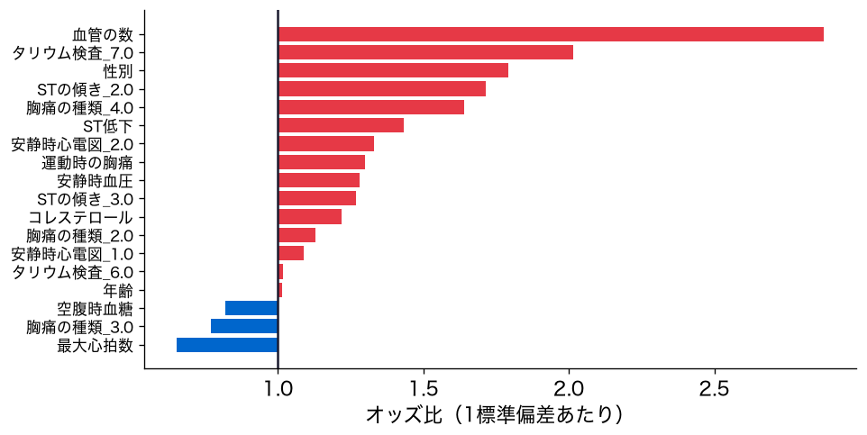

- 1より大きい列は、なりやすい向き。1より小さい列は、なりにくい向き

## 血管の数と最大心拍数

4節 ② オッズ比●●●●●●○

- いちばん大きいのは血管の数で2.88、次がタリウム検査7の2.01
- いちばん小さいのは最大心拍数の0.65

## 1標準偏差あたり

4節 ② オッズ比●●●●●●●

- この式は、標準化した手がかりで作っている
- だから、オッズ比は「1標準偏差増えると、何倍か」
- ほかの列の値が同じなら、という条件付き（第4回の「合わせて読む」）

## 1単位あたりに戻す

4節 ③ 1単位に戻す●○○○○○○○

- 1標準偏差では、医師に伝えにくい
- 標準化した係数を標準偏差で割れば、1単位あたり（第5回と同じ）
- 標準偏差は、`StandardScaler`が`scale_`に覚えている

## お手本：血管1本あたり

4節 ③ 1単位に戻す●●○○○○○○

```python
scale = pd.Series(pipe[0].scale_, index=X.columns)
print(round(scale['血管の数'], 3))
print(round(np.exp(coef['血管の数'] / scale['血管の数']), 2))
```

```
0.959
3.01
```

## 血管1本で3.01倍

4節 ③ 1単位に戻す●●●○○○○○

- 血管の数の標準偏差は0.959で、1本とほぼ同じ
- 透視で写った太い血管が1本多いと、心臓病のオッズは3.01倍

## TODO③：10拍高いと

4節 ③ 1単位に戻す●●●●○○○○

```python
# TODO: 最大心拍数が 10 拍高いときのオッズ比を表示する
# ヒント: 1拍あたりの係数は coef['最大心拍数'] / scale['最大心拍数']
#         それを 10 倍して np.exp に通す
...
```

- 小数第2位まで表示する

## やってみよう：4節とTODO③

4節 ③ 1単位に戻す●●●●●○○○

- 4節のお手本を実行し、オッズ比を確かめる
- TODO③で、最大心拍数が10拍高いときのオッズ比を出す

動画の人は、ここで一時停止。

## 答え合わせ：TODO③

4節 ③ 1単位に戻す●●●●●●○○

```python
per1 = coef['最大心拍数'] / scale['最大心拍数']   # 1拍あたり
print(round(np.exp(10 * per1), 2))
```

```
0.83
```

- 最大心拍数が10拍高いと、オッズは0.83倍。2割ほど小さくなる

## オッズ比は確率の何倍ではない

4節 ③ 1単位に戻す●●●●●●●○

```python
print(round(0.3 / 0.7, 2), round(0.6 / 0.4, 2))
print(round((0.6 / 0.4) / (0.3 / 0.7), 1))   # オッズは何倍か
```

```
0.43 1.5
3.5
```

- 確率が0.3から0.6（2倍）になると、オッズは0.43から1.5で3.5倍

## 患者には確率で

4節 ③ 1単位に戻す●●●●●●●●

- オッズ比は、どの検査値が効くかを読む道具
- 患者に伝えるときは、6節のように、その人の確率で伝える